# Supplementary material for “A practical method of estimating the time-varying degree of vowel nasalization from acoustic features”

Christopher Carignan

4 February, 2021

## Introduction

This R Markdown document provides the R code necessary to recreate models and figures appearing in: Carignan, C. (2021). “A practical method of estimating the time-varying degree of vowel nasalization from acoustic features.” *Journal of the Acoustical Society of America, 149*(2), 911–922, DOI: 10.1121/10.0002925

## Preparing the data

The data

Let’s begin by loading the required R packages:

```r
require(ggplot2)
require(brms)
require(parallel)
require(tidybayes)
require(dplyr)
require(extraDistr)
require(HDInterval)
require(mgcv)
require(itsadug)
require(ggpubr)
```

Now we’ll pre-allocate some variables and data frames:

```r
# speaker names
speakers <- c('S01','S02','S03','S04','S05','S06')

# random seed for replicability
seed <- 1

# pre-allocate some stuff
naf.corrs <- c()
naf_red.corrs <- c()
a1p0.corrs <- c()
a1p0_comp.corrs <- c()
a1p1.corrs <- c()
a1p1_comp.corrs <- c()

# pre-allocate some more stuff
naf.diffs <- c()
naf_red.diffs <- c()
a1p0.diffs <- c()
a1p0_comp.diffs <- c()
a1p1.diffs <- c()
a1p1_comp.diffs <- c()

# more pre-allocation stuff
all.dat <- c()
oral.num <- c()
nasal.num <- c()
```

## Main loop: data loading, extraction, and measurement by speaker and vowel

Now we’ve got the heart of the code, which loops through all of the speaker data to perform various measurements and add the results to the pre-allocated data frames:

```r
# loop through the speaker list
for (speaker in speakers) {
  # pre-allocate some stuff
  naf.corrs[[speaker]] <- c()
  naf_red.corrs[[speaker]] <- c()
  a1p0.corrs[[speaker]] <- c()
  a1p0_comp.corrs[[speaker]] <- c()
  a1p1.corrs[[speaker]] <- c()
  a1p1_comp.corrs[[speaker]] <- c()

  # load the speaker's data set
  nas.dat <- read.csv(file=paste0('data/',speaker,'_data.csv'))

  # create the H1-H2 metric
  nas.dat$h1h2 <- nas.dat$amp_h1 - nas.dat$amp_h2


  # create the training data set
  train_ind <- c()
  for (vowel in unique(nas.dat$vowel)) {
    # set the random seed to make sure that the training and testing data are split in the same way every time
    set.seed(seed)

    # get the speaker's data for this vowel
    vowel.dat <- nas.dat[nas.dat$vowel==vowel,]

    # scale the nasalance data for the vowel
    nas.dat$nasalance_z[nas.dat$vowel==vowel] <- scale(vowel.dat$nasalance)

    # randomly select 75% of the tokens to be used for training
    train_tok <- sample(unique(vowel.dat$token), size = round(0.75*length(unique(vowel.dat$token))))

    # get the row numbers corresponding to all of the data for these training tokens
    train_ind <- c(train_ind, as.numeric(row.names(vowel.dat[vowel.dat$token %in% train_tok,])))
  }

  # column names corresponding to different sets of acoustic features
  nas.features <- c('freq_f1','freq_f2','freq_f3',
                    'amp_f1','amp_f2','amp_f3',
                    'width_f1','width_f2','width_f3',
                    'amp_p0','a1p0','a1p0_compensated','p0prominence',
                    'amp_p1','a1p1','a1p1_compensated',
                    'a3p0','h1h2','murmur','cog')
  mfc.features <- c(paste0('mfcc0',1:9),
                    paste0('mfcc',10:13))
  all.features <- c(nas.features, mfc.features)


  # PCA of all acoustic features (for full NAF method)
  pca.full <- stats::prcomp(nas.dat[,all.features], scale=T, center=T)

  # PCA of only MFCCs (for reduced NAF method)
  pca.red <- stats::prcomp(nas.dat[,mfc.features], scale=T, center=T)



  # split tokens into low and high degrees of nasalance
  lo <- quantile(nas.dat$nasalance_z[train_ind], c(0.25))
  hi <- quantile(nas.dat$nasalance_z[train_ind], c(0.75))


  # 'oral' tokens: lower quartile of nasalance
  oral.dat  <- nas.dat[train_ind,]
  oral.dat  <- oral.dat[oral.dat$nasalance_z<lo,]
  oral.dat$nasality <- 'oral'
  oral.num <- c(oral.num,nrow(oral.dat))

  # 'nasal' tokens: upper quartile of nasalance
  nasal.dat <- nas.dat[train_ind,]
  nasal.dat <- nasal.dat[nasal.dat$nasalance_z>hi,]
  nasal.dat$nasality <- 'nasal'
  nasal.num <- c(nasal.num,nrow(nasal.dat))


  # combine oral and nasal tokens
  train.dat <- rbind(oral.dat,nasal.dat)
  train.dat <- train.dat[,c('nasality',all.features)]
  train.dat$nasality <- as.factor(train.dat$nasality)

  # get the indexes of the training items
  train_ind2 <- as.numeric(row.names(train.dat))


  # # # # # # # # # #
  # full NAF method #
  # # # # # # # # # #

  # create a data frame with the PC scores for the full acoustic feature set
  pca.dat <- cbind.data.frame(train.dat$nasality, pca.full$x[train_ind2,])
  colnames(pca.dat)[1] <- 'nasality'
  pca.dat$nasality <- as.character(pca.dat$nasality)

  # convert 'oral' and 'nasal' to numeric 0 and 1
  pca.dat$nasality[pca.dat$nasality=='oral'] <- 0
  pca.dat$nasality[pca.dat$nasality=='nasal'] <- 1
  pca.dat$nasality <- as.numeric(pca.dat$nasality)

  # build the linear regression model with PC scores as predictors
  lm.mod <- lm(nasality ~ ., data=pca.dat)

  # generate NAF values for the testing data
  NAF.full <- predict(lm.mod, newdata=as.data.frame(pca.full$x[-train_ind,]), type='response')


  # # # # # # # # # # # #
  # reduced NAF method  #
  # # # # # # # # # # # #

  # create a data frame with the PC scores for the reduced acoustic feature set (MFCCs only)
  pca.dat <- cbind.data.frame(train.dat$nasality, pca.red$x[train_ind2,])
  colnames(pca.dat)[1] <- 'nasality'
  pca.dat$nasality <- as.character(pca.dat$nasality)

  # convert 'oral' and 'nasal' to numeric 0 and 1
  pca.dat$nasality[pca.dat$nasality=='oral'] <- 0
  pca.dat$nasality[pca.dat$nasality=='nasal'] <- 1
  pca.dat$nasality <- as.numeric(pca.dat$nasality)

  # build the linear regression model with PC scores as predictors
  lm.mod <- lm(nasality ~ ., data=pca.dat)

  # generate NAF values for the testing data
  NAF.red <- predict(lm.mod, newdata=as.data.frame(pca.red$x[-train_ind,]), type='response')


  # get the testing data (i.e. all of the tokens that weren't used in training)
  # and add the NAF values from the full and reduced methods
  test.dat <- cbind(nas.dat[-train_ind,], NAF.full, NAF.red)

  # scale the values of all metrics to be tested
  test.dat$nasalance_z      <- scale(test.dat$nasalance_z)
  test.dat$a1p0             <- scale(-test.dat$a1p0)
  test.dat$a1p0_compensated <- scale(-test.dat$a1p0_compensated)
  test.dat$a1p1             <- scale(-test.dat$a1p1)
  test.dat$a1p1_compensated <- scale(-test.dat$a1p1_compensated)
  test.dat$NAF              <- scale(test.dat$NAF.full)
  test.dat$NAF.red          <- scale(test.dat$NAF.red)

  # loop through all of the individual tokens (500 ms windows) in the speaker's data set
  for (token in unique(test.dat$token)) {
    # get the data for this token
    token.dat <- test.dat[test.dat$token==token,]

    # smooth all measurements for the token
    token.dat$NAF               <- stats::smooth(token.dat$NAF)
    token.dat$NAF.red           <- stats::smooth(token.dat$NAF.red)
    token.dat$a1p0              <- stats::smooth(token.dat$a1p0)
    token.dat$a1p0_compensated  <- stats::smooth(token.dat$a1p0_compensated)
    token.dat$a1p1              <- stats::smooth(token.dat$a1p1)
    token.dat$a1p1_compensated  <- stats::smooth(token.dat$a1p1_compensated)

    # replace the data in the original table with the smoothed token data
    test.dat$NAF[test.dat$token==token]               <- token.dat$NAF
    test.dat$NAF.red[test.dat$token==token]           <- token.dat$NAF.red
    test.dat$a1p0[test.dat$token==token]              <- token.dat$a1p0
    test.dat$a1p0_compensated[test.dat$token==token]  <- token.dat$a1p0_compensated
    test.dat$a1p1[test.dat$token==token]              <- token.dat$a1p1
    test.dat$a1p1_compensated[test.dat$token==token]  <- token.dat$a1p1_compensated


    # since the 500 window (100 samples) is centered on the point of maximum velocity in the nasalance signal,
    # we will take sample 50 as the point of peak nasalance velocity (i.e. the nasalance 'onset')
    nas.onset <- 50

    # find the temporal lag (ms) between the velocity peak in the nasalance signal and the velocity peak in each test metric
    naf.diff        <- 5*(which.max(diff(token.dat$NAF)) - nas.onset)
    naf_red.diff    <- 5*(which.max(diff(token.dat$NAF.red)) - nas.onset)
    a1p0.diff       <- 5*(which.max(diff(token.dat$a1p0)) - nas.onset)
    a1p0_comp.diff  <- 5*(which.max(diff(token.dat$a1p0_compensated)) - nas.onset)
    a1p1.diff       <- 5*(which.max(diff(token.dat$a1p1)) - nas.onset)
    a1p1_comp.diff  <- 5*(which.max(diff(token.dat$a1p_compensated)) - nas.onset)

    # add the temporal lag/difference data to the respective data frames
    vowel <- unique(token.dat$vowel)

    naf.diffs <- rbind.data.frame(naf.diffs,
                                  c(speaker, vowel, naf.diff, 'NAF'))
    naf_red.diffs <- rbind.data.frame(naf_red.diffs,
                                      c(speaker, vowel, naf_red.diff, 'NAF red.'))
    a1p0.diffs <- rbind.data.frame(a1p0.diffs,
                                   c(speaker, vowel, a1p0.diff, 'A1-P0'))
    a1p0_comp.diffs <- rbind.data.frame(a1p0_comp.diffs,
                                        c(speaker, vowel, a1p0_comp.diff, 'A1-P0 comp.'))
    a1p1.diffs <- rbind.data.frame(a1p1.diffs,
                                   c(speaker, vowel, a1p1.diff, 'A1-P1'))
    a1p1_comp.diffs <- rbind.data.frame(a1p1_comp.diffs,
                                        c(speaker, vowel, a1p0_comp.diff, 'A1-P1 comp.'))
  }

  # rename columns of the temporal lag data frames
  colnames(naf.diffs)       <- c('speaker','vowel','ons.diff','method')
  colnames(naf_red.diffs)   <- c('speaker','vowel','ons.diff','method')
  colnames(a1p0.diffs)      <- c('speaker','vowel','ons.diff','method')
  colnames(a1p0_comp.diffs) <- c('speaker','vowel','ons.diff','method')
  colnames(a1p1.diffs)      <- c('speaker','vowel','ons.diff','method')
  colnames(a1p1_comp.diffs) <- c('speaker','vowel','ons.diff','method')


  # for each vowel, get the correlations between each metric and the nasalance signal
  for (vowel in unique(test.dat$vowel)) {

    # get the correlation between nasalance and the full NAF
    naf.corrs[[speaker]][vowel] <- as.numeric(
      cor.test(
        test.dat$nasalance_z[test.dat$vowel==vowel], test.dat$NAF[test.dat$vowel==vowel]
      )[4] # index 4 is the correlation coefficient
    )

    # get the correlation between nasalance and the reduced NAF
    naf_red.corrs[[speaker]][vowel] <- as.numeric(
      cor.test(
        test.dat$nasalance_z[test.dat$vowel==vowel], test.dat$NAF.red[test.dat$vowel==vowel]
      )[4] # index 4 is the correlation coefficient
    )

    # get the correlation between nasalance and A1-P0
    a1p0.corrs[[speaker]][vowel] <- as.numeric(
      cor.test(
        test.dat$nasalance_z[test.dat$vowel==vowel], test.dat$a1p0[test.dat$vowel==vowel]
      )[4] # index 4 is the correlation coefficient
    )

    # get the correlation between nasalance and formant-compensated A1-P0
    a1p0_comp.corrs[[speaker]][vowel] <- as.numeric(
      cor.test(
        test.dat$nasalance_z[test.dat$vowel==vowel], test.dat$a1p0_compensated[test.dat$vowel==vowel]
      )[4] # index 4 is the correlation coefficient
    )

    # get the correlation between nasalance and A1-P1
    a1p1.corrs[[speaker]][vowel] <- as.numeric(
      cor.test(
        test.dat$nasalance_z[test.dat$vowel==vowel], test.dat$a1p1[test.dat$vowel==vowel]
      )[4] # index 4 is the correlation coefficient
    )

    # get the correlation between nasalance and formant-compensated A1-P1
    a1p1_comp.corrs[[speaker]][vowel] <- as.numeric(
      cor.test(
        test.dat$nasalance_z[test.dat$vowel==vowel], test.dat$a1p1_compensated[test.dat$vowel==vowel]
      )[4] # index 4 is the correlation coefficient
    )
  }

  # add the speaker's testing data to a full data set for later GAMM analysis
  all.dat <- rbind.data.frame(all.dat, cbind(speaker, test.dat))
}

# combine the temporal lag data into a single data frame
diff.dat <- rbind.data.frame(
  naf.diffs, naf_red.diffs, a1p0.diffs, a1p0_comp.diffs, a1p1.diffs, a1p1_comp.diffs
)
# convert classes of variables as appropriate
diff.dat$speaker  <- as.factor(diff.dat$speaker)
diff.dat$vowel    <- as.factor(diff.dat$vowel)
diff.dat$ons.diff <- as.numeric(diff.dat$ons.diff)
diff.dat$method   <- factor(diff.dat$method, levels=c('NAF','NAF red.','A1-P0','A1-P0 comp.','A1-P1','A1-P1 comp.'))
```

## Correlation with nasalance

We can now look at the global averages and SDs of the correlations with nasalance to get an idea of how well each metric performs:

```r
# full NAF
mean(unlist(naf.corrs))
```

```
## [1] 0.913509
```

```r
sd(unlist(naf.corrs))
```

```
## [1] 0.06194171
```

```r
# reduced NAF
mean(unlist(naf_red.corrs))
```

```
## [1] 0.8451021
```

```r
sd(unlist(naf_red.corrs))
```

```
## [1] 0.09445039
```

```r
# A1-P0
mean(unlist(a1p0.corrs))
```

```
## [1] 0.6599351
```

```r
sd(unlist(a1p0.corrs))
```

```
## [1] 0.3960054
```

```r
# formant-compensated A1-P0
mean(unlist(a1p0_comp.corrs))
```

```
## [1] 0.685911
```

```r
sd(unlist(a1p0_comp.corrs))
```

```
## [1] 0.3852224
```

```r
# A1-P1
mean(unlist(a1p1.corrs))
```

```
## [1] 0.3613675
```

```r
sd(unlist(a1p1.corrs))
```

```
## [1] 0.5041735
```

```r
# formant-compensated A1-P1
mean(unlist(a1p1_comp.corrs))
```

```
## [1] 0.3898438
```

```r
sd(unlist(a1p1_comp.corrs))
```

```
## [1] 0.480162
```

Let’s ombine all of the correlation data into one table…

```r
# NB: substr(X,1,3) extracts the speaker names, while substr(X,5,6) extracts the vowel names
acc.dat <- rbind.data.frame(
  cbind(substr(names(unlist(naf.corrs)),1,3),
        substr(names(unlist(naf.corrs)),5,6),
        unlist(naf.corrs),'NAF'),
  cbind(substr(names(unlist(naf_red.corrs)),1,3),
        substr(names(unlist(naf_red.corrs)),5,6),
        unlist(naf.corrs),'NAF red.'),
  cbind(substr(names(unlist(a1p0.corrs)),1,3),
        substr(names(unlist(naf.corrs)),5,6),
        unlist(a1p0.corrs),'A1-P0'),
  cbind(substr(names(unlist(a1p0_comp.corrs)),1,3),
        substr(names(unlist(naf.corrs)),5,6),
        unlist(a1p0_comp.corrs),'A1-P0 comp.'),
  cbind(substr(names(unlist(a1p1.corrs)),1,3),
        substr(names(unlist(naf.corrs)),5,6),
        unlist(a1p1.corrs),'A1-P1'),
  cbind(substr(names(unlist(a1p1_comp.corrs)),1,3),
        substr(names(unlist(naf.corrs)),5,6),
        unlist(a1p1_comp.corrs),'A1-P1 comp.')
)
colnames(acc.dat) <- c('speaker','vowel','accuracy','method')

# convert classes of variables as appropriate
acc.dat$speaker   <- as.factor(acc.dat$speaker)
acc.dat$vowel     <- as.factor(acc.dat$vowel)
acc.dat$accuracy  <- as.numeric(acc.dat$accuracy)
acc.dat$method    <- factor(acc.dat$method, levels=c('NAF','NAF red.','A1-P0','A1-P0 comp.','A1-P1','A1-P1 comp.'))
acc.dat$R2        <- acc.dat$accuracy^2 # R^2
```

…and extract the correlation coefficents by vowel and store them in separate data frames:

```r
vowels <- c('i','ih','e','eh','ae','a','ah','oh','o','uh','u')
vowel.acc.naf <- c()
vowel.acc.naf_red <- c()
vowel.acc.a1p0 <- c()
vowel.acc.a1p0_comp <- c()
vowel.acc.a1p1 <- c()
vowel.acc.a1p1_comp <- c()
for (vowel in vowels) {
  for (speaker in speakers) {
    if (vowel %in% names(naf.corrs[[speaker]])) {
      vowel.acc.naf[[vowel]][speaker]       <- naf.corrs[[speaker]][[vowel]]
      vowel.acc.naf_red[[vowel]][speaker]   <- naf_red.corrs[[speaker]][[vowel]]
      vowel.acc.a1p0[[vowel]][speaker]      <- a1p0.corrs[[speaker]][[vowel]]
      vowel.acc.a1p0_comp[[vowel]][speaker] <- a1p0_comp.corrs[[speaker]][[vowel]]
      vowel.acc.a1p1[[vowel]][speaker]      <- a1p1.corrs[[speaker]][[vowel]]
      vowel.acc.a1p1_comp[[vowel]][speaker] <- a1p1_comp.corrs[[speaker]][[vowel]]
    }
  }
}
```

We can now look at the separate average and SD of correlation coefficients by vowel and speaker (example below for one vowel (/i/) and one speaker (S01):)

```r
# average and SD for vowel /i/ (averaged across speakers)
# these values appear in Table I of the paper
mean(vowel.acc.naf$i)
```

```
## [1] 0.8764515
```

```r
sd(vowel.acc.naf$i)
```

```
## [1] 0.1244709
```

```r
# average and SD for speaker S01 (averaged across vowels)
# these values appear in Table II of the paper
mean(naf.corrs$S01)
```

```
## [1] 0.9350872
```

```r
sd(naf.corrs$S01)
```

```
## [1] 0.03230117
```

## Bayesian regression models (BRMs)

The BRMs can take a long time to run if you’re building them for the first time, so let’s enable parallel processing. If you have the model .Rds file from Github, the *brm* function will simply load that instead of building a new model:

```r
core.num <- parallel::detectCores()
options(mc.cores=core.num)
set.seed(seed)
```

### BRM of R<sup>2</sup> values

The inverse cumulative density function can be used to report the HDI range for the sigma value we’ll use:

```r
HDInterval::inverseCDF(c(0.025,0.975), phcauchy, sigma=0.01)
```

```
## [1] 0.0004103611 0.2545175249
```

```r
# This corresponds to a 95% HDI at sigma 0.01 = [0, 0.25] R^2
```

We’ll now generate the following weakly informative priors for the R<sup>2</sup> model:

- NAF R<sup>2</sup> is between 0 and 1
- The difference between the other methods and NAF are between -1 and +1
- The model SD and the random intercept SD HDI = [0, 0.25]

```r
priors <- c(
  prior(normal(0.5,0.25), class=Intercept),
  prior(normal(0,0.5), class=b, coef=methodNAFred.),
  prior(normal(0,0.5), class=b, coef=methodA1MP0),
  prior(normal(0,0.5), class=b, coef=methodA1MP0comp.),
  prior(normal(0,0.5), class=b, coef=methodA1MP1),
  prior(normal(0,0.5), class=b, coef=methodA1MP1comp.),
  prior(cauchy(0,0.01), class=sd),
  prior(cauchy(0,0.01), class=sigma),
  prior(lkj(2), class=cor)
)
```

Now we can build the model with the above priors and random effects for speaker and vowel:

```r
acc.mod <- brms::brm(R2 ~ method +
                       (1 + method | speaker) +
                       (1 + method | vowel),
                     data = acc.dat,
                     family = gaussian(),
                     seed = seed,
                     iter = 2000,
                     warmup = 1000,
                     prior = priors,
                     chains = 4,
                     cores = core.num,
                     control = list(adapt_delta = 0.9999,
                                    max_treedepth = 15),
                     file = 'models/acc_brms'
)
```

If desired, we can get a summary of the model:

```r
summary(acc.mod)
```

```
##  Family: gaussian
##   Links: mu = identity; sigma = identity
## Formula: R2 ~ method + (1 + method | speaker) + (1 + method | vowel)
##    Data: acc.dat (Number of observations: 372)
## Samples: 4 chains, each with iter = 2000; warmup = 1000; thin = 1;
##          total post-warmup samples = 4000
##
## Group-Level Effects:
## ~speaker (Number of levels: 6)
##                                        Estimate Est.Error l-95% CI u-95% CI
## sd(Intercept)                              0.07      0.03     0.03     0.15
## sd(methodNAFred.)                          0.01      0.01     0.00     0.05
## sd(methodA1MP0)                            0.02      0.03     0.00     0.10
## sd(methodA1MP0comp.)                       0.02      0.03     0.00     0.10
## sd(methodA1MP1)                            0.02      0.03     0.00     0.09
## sd(methodA1MP1comp.)                       0.02      0.02     0.00     0.08
## cor(Intercept,methodNAFred.)              -0.03      0.33    -0.64     0.62
## cor(Intercept,methodA1MP0)                 0.05      0.32    -0.57     0.64
## cor(methodNAFred.,methodA1MP0)             0.00      0.34    -0.65     0.65
## cor(Intercept,methodA1MP0comp.)            0.02      0.32    -0.61     0.62
## cor(methodNAFred.,methodA1MP0comp.)       -0.00      0.34    -0.64     0.61
## cor(methodA1MP0,methodA1MP0comp.)          0.06      0.34    -0.62     0.67
## cor(Intercept,methodA1MP1)                 0.02      0.32    -0.59     0.63
## cor(methodNAFred.,methodA1MP1)             0.00      0.33    -0.61     0.63
## cor(methodA1MP0,methodA1MP1)              -0.01      0.33    -0.62     0.61
## cor(methodA1MP0comp.,methodA1MP1)         -0.02      0.34    -0.65     0.61
## cor(Intercept,methodA1MP1comp.)            0.02      0.33    -0.62     0.66
## cor(methodNAFred.,methodA1MP1comp.)        0.00      0.33    -0.64     0.63
## cor(methodA1MP0,methodA1MP1comp.)         -0.02      0.33    -0.64     0.60
## cor(methodA1MP0comp.,methodA1MP1comp.)    -0.02      0.33    -0.63     0.61
## cor(methodA1MP1,methodA1MP1comp.)          0.04      0.33    -0.61     0.66
##                                        Rhat Bulk_ESS Tail_ESS
## sd(Intercept)                          1.00     1538     2146
## sd(methodNAFred.)                      1.00     3987     2268
## sd(methodA1MP0)                        1.00     2028     2316
## sd(methodA1MP0comp.)                   1.00     2184     2466
## sd(methodA1MP1)                        1.00     3186     2376
## sd(methodA1MP1comp.)                   1.00     3586     2478
## cor(Intercept,methodNAFred.)           1.00     6285     3086
## cor(Intercept,methodA1MP0)             1.00     5917     3180
```

[output cut: 61 more lines]

```
##                  Estimate Est.Error l-95% CI u-95% CI Rhat Bulk_ESS Tail_ESS
## Intercept            0.83      0.04     0.75     0.92 1.00     1708     2258
## methodNAFred.        0.00      0.04    -0.07     0.08 1.00     3100     3101
## methodA1MP0         -0.24      0.04    -0.33    -0.16 1.00     3402     2928
## methodA1MP0comp.    -0.22      0.04    -0.30    -0.14 1.00     3242     3004
## methodA1MP1         -0.45      0.06    -0.56    -0.33 1.00     2202     2806
## methodA1MP1comp.    -0.45      0.06    -0.57    -0.33 1.00     2298     2561
##
## Family Specific Parameters:
##       Estimate Est.Error l-95% CI u-95% CI Rhat Bulk_ESS Tail_ESS
## sigma     0.22      0.01     0.20     0.24 1.00     4556     2849
##
## Samples were drawn using sampling(NUTS). For each parameter, Bulk_ESS
## and Tail_ESS are effective sample size measures, and Rhat is the potential
## scale reduction factor on split chains (at convergence, Rhat = 1).
```

Lets get the posterior values from the BRM for plotting and generating summary statistics:

```r
posts <- brms::posterior_samples(acc.mod, pars='b_') %>%
  dplyr::mutate('NAF (full)' = b_Intercept,
                'NAF (red.)' = b_Intercept + b_methodNAFred.,
                'A1-P0' = b_Intercept + b_methodA1MP0,
                'A1-P0 comp.' = b_Intercept + b_methodA1MP0comp.,
                'A1-P1' = b_Intercept + b_methodA1MP1,
                'A1-P1 comp.' = b_Intercept + b_methodA1MP1comp.
  ) %>%
  dplyr::select('NAF (full)', 'NAF (red.)', 'A1-P0', 'A1-P0 comp.', 'A1-P1', 'A1-P1 comp.') %>%
  tidyr::gather(method, R2)
```

### Figure 4

Now that we have the posteriors, we can create Figure 4 from the paper:

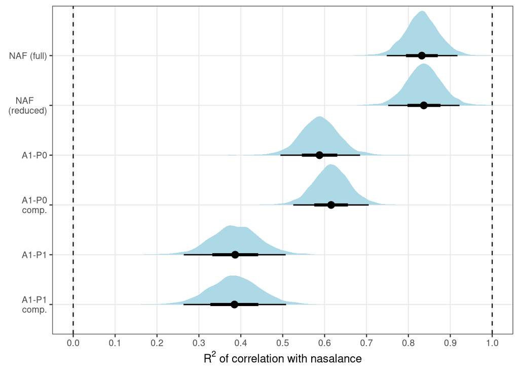

```r
posts %>%
  ggplot(aes(x = R2, y = method)) +
  geom_vline(xintercept=0,lty=2) +
  geom_vline(xintercept=1,lty=2) +
  geom_halfeyeh(fill='lightblue') +
  coord_cartesian(xlim=c(0,1)) +
  ylab('') + xlab(expression(R^2~'of correlation with nasalance')) +
  scale_x_continuous(breaks=seq(0,1,0.1),minor_breaks=seq(0,1,0.1)) +
  scale_y_discrete(limits=c('A1-P1 comp.','A1-P1','A1-P0 comp.','A1-P0','NAF (red.)','NAF (full)'), labels=c('A1-P1\ncomp.','A1-P1','A1-P0\ncomp.','A1-P0','NAF     \n(reduced)','NAF (full)')) +
  theme_bw() + theme(plot.margin = unit(c(0.2,0.2,0.2,-0.2), 'cm'))
```

### BRM of R<sup>2</sup> values: summary statistics

In order to generate the summary statistics that are reported in the paper, we first need to get the fixed effects from the BRM:

```r
acc_fixed <- fixef(acc.mod)
```

We’ll get the lower and lower bounds of the 95% credible interval for the full NAF values (the model intercept):

```r
# Lower
acc_fixed[1,3]
```

```
## [1] 0.7483283
```

```r
# Upper
acc_fixed[1,4]
```

```
## [1] 0.9170527
```

Now we can find the differences for the other methods, in comparison to the model intercept (i.e. the full NAF method)…

```r
acc_diffs <- brms::posterior_samples(acc.mod, pars = 'b_') %>%
  dplyr::mutate(
    NAF = b_Intercept,
    NAFred = b_Intercept + b_methodNAFred.,
    A1P0 = b_Intercept + b_methodA1MP0,
    A1P0comp = b_Intercept + b_methodA1MP0comp.,
    A1P1 = b_Intercept + b_methodA1MP1,
    A1P1comp = b_Intercept + b_methodA1MP1comp.,
    NAFred.diff = NAFred - NAF,
    A1P0.diff = A1P0 - NAF,
    A1P0comp.diff = A1P0comp - NAF,
    A1P1.diff = A1P1 - NAF,
    A1P1comp.diff = A1P1comp - NAF
  )
```

…and generate the 95% CIs that are reported in the article:

```r
quantile(acc_diffs$NAFred.diff, probs = c(0.025, 0.975))
```

```
##        2.5%       97.5%
## -0.07308670  0.08233806
```

```r
quantile(acc_diffs$A1P0.diff, probs = c(0.025, 0.975))
```

```
##       2.5%      97.5%
## -0.3297829 -0.1576631
```

```r
quantile(acc_diffs$A1P0comp.diff, probs = c(0.025, 0.975))
```

```
##       2.5%      97.5%
## -0.2987537 -0.1361069
```

```r
quantile(acc_diffs$A1P1.diff, probs = c(0.025, 0.975))
```

```
##       2.5%      97.5%
## -0.5632699 -0.3329705
```

```r
quantile(acc_diffs$A1P1comp.diff, probs = c(0.025, 0.975))
```

```
##       2.5%      97.5%
## -0.5661260 -0.3312858
```

### BRM of temporal lag measure

The inverse cumulative density function can be used to report the HDI range for the sigma value we’ll use:

```r
HDInterval::inverseCDF(c(0.025,0.975), phcauchy, sigma=2)
```

```
## [1]  0.07858532 50.90339918
```

```r
# This corresponds to a 95% HDI at sigma 2 = [0, 51] ms
```

```r
priors <- c(
  prior(normal(0,100), class=Intercept),
  prior(normal(0,50), class=b, coef=methodNAFred.),
  prior(normal(0,50), class=b, coef=methodA1MP0),
  prior(normal(0,50), class=b, coef=methodA1MP0comp.),
  prior(normal(0,50), class=b, coef=methodA1MP1),
  prior(normal(0,50), class=b, coef=methodA1MP1comp.),
  prior(cauchy(0,2), class=sd),
  prior(cauchy(0,2), class=sigma),
  prior(lkj(2), class=cor)
)
```

Now we can build the model with the above priors and random effects for speaker and vowel:

```r
diff.mod <- brm(ons.diff ~ method +
                  (1 + method | speaker) +
                  (1 + method | vowel),
                family = gaussian(),
                data = diff.dat,
                seed = seed,
                iter = 2000,
                warmup = 1000,
                prior = priors,
                chains = 4,
                cores = core.num,
                control = list(adapt_delta = 0.9999,
                               max_treedepth = 15),
                file = 'models/diff_brms'
)
```

If desired, we can get a summary of the model:

```r
summary(diff.mod)
```

```
##  Family: gaussian
##   Links: mu = identity; sigma = identity
## Formula: ons.diff ~ method + (1 + method | speaker) + (1 + method | vowel)
##    Data: diff.dat (Number of observations: 1506)
## Samples: 4 chains, each with iter = 2000; warmup = 1000; thin = 1;
##          total post-warmup samples = 4000
##
## Group-Level Effects:
## ~speaker (Number of levels: 6)
##                                        Estimate Est.Error l-95% CI u-95% CI
## sd(Intercept)                              3.31      3.32     0.10    12.05
## sd(methodNAFred.)                          5.24      7.18     0.09    26.52
## sd(methodA1MP0)                            2.73      3.22     0.07    11.80
## sd(methodA1MP0comp.)                       2.86      3.59     0.07    13.43
## sd(methodA1MP1)                            3.53      4.69     0.08    16.77
## sd(methodA1MP1comp.)                       2.75      3.58     0.07    12.03
## cor(Intercept,methodNAFred.)               0.03      0.33    -0.60     0.64
## cor(Intercept,methodA1MP0)                 0.00      0.34    -0.65     0.63
## cor(methodNAFred.,methodA1MP0)            -0.00      0.33    -0.64     0.64
## cor(Intercept,methodA1MP0comp.)            0.01      0.34    -0.62     0.64
## cor(methodNAFred.,methodA1MP0comp.)        0.01      0.34    -0.64     0.65
## cor(methodA1MP0,methodA1MP0comp.)          0.01      0.33    -0.62     0.64
## cor(Intercept,methodA1MP1)                -0.03      0.33    -0.64     0.61
## cor(methodNAFred.,methodA1MP1)             0.00      0.33    -0.62     0.64
## cor(methodA1MP0,methodA1MP1)              -0.01      0.33    -0.62     0.61
## cor(methodA1MP0comp.,methodA1MP1)         -0.00      0.34    -0.64     0.65
## cor(Intercept,methodA1MP1comp.)            0.01      0.32    -0.62     0.63
## cor(methodNAFred.,methodA1MP1comp.)        0.01      0.34    -0.62     0.65
## cor(methodA1MP0,methodA1MP1comp.)          0.00      0.33    -0.63     0.64
## cor(methodA1MP0comp.,methodA1MP1comp.)     0.02      0.34    -0.64     0.66
## cor(methodA1MP1,methodA1MP1comp.)         -0.00      0.33    -0.63     0.62
##                                        Rhat Bulk_ESS Tail_ESS
## sd(Intercept)                          1.00     2322     2315
## sd(methodNAFred.)                      1.00     2577     2401
## sd(methodA1MP0)                        1.00     4913     2534
## sd(methodA1MP0comp.)                   1.00     3909     2408
## sd(methodA1MP1)                        1.00     3914     2157
## sd(methodA1MP1comp.)                   1.00     3697     1896
## cor(Intercept,methodNAFred.)           1.00     5823     2873
## cor(Intercept,methodA1MP0)             1.00     7009     2191
```

[output cut: 61 more lines]

```
##                  Estimate Est.Error l-95% CI u-95% CI Rhat Bulk_ESS Tail_ESS
## Intercept           10.51      8.70    -6.91    27.29 1.00     2219     2575
## methodNAFred.      -24.44     10.77   -45.58    -3.33 1.00     2892     2529
## methodA1MP0         18.70      9.83    -0.52    38.08 1.00     3481     3023
## methodA1MP0comp.    13.80      9.75    -6.10    33.20 1.00     2814     2804
## methodA1MP1          2.68     10.21   -17.55    22.59 1.00     3424     2918
## methodA1MP1comp.    13.69      9.77    -5.10    32.50 1.00     3400     2734
##
## Family Specific Parameters:
##       Estimate Est.Error l-95% CI u-95% CI Rhat Bulk_ESS Tail_ESS
## sigma   108.32      2.00   104.40   112.43 1.00     6360     2901
##
## Samples were drawn using sampling(NUTS). For each parameter, Bulk_ESS
## and Tail_ESS are effective sample size measures, and Rhat is the potential
## scale reduction factor on split chains (at convergence, Rhat = 1).
```

Lets get the posterior values from the BRM for plotting and generating summary statistics:

```r
posts <- brms::posterior_samples(diff.mod, pars='b_') %>%
  dplyr::mutate('NAF (full)' = b_Intercept,
                'NAF (red.)' = b_Intercept + b_methodNAFred.,
                'A1-P0' = b_Intercept + b_methodA1MP0,
                'A1-P0 comp.' = b_Intercept + b_methodA1MP0comp.,
                'A1-P1' = b_Intercept + b_methodA1MP1,
                'A1-P1 comp.' = b_Intercept + b_methodA1MP1comp.) %>%
  dplyr::select('NAF (full)', 'NAF (red.)', 'A1-P0', 'A1-P0 comp.', 'A1-P1', 'A1-P1 comp.') %>%
  tidyr::gather(method, ons.diff)
```

### Figure 5

Now that we have the posteriors, we can create Figure 5 from the paper:

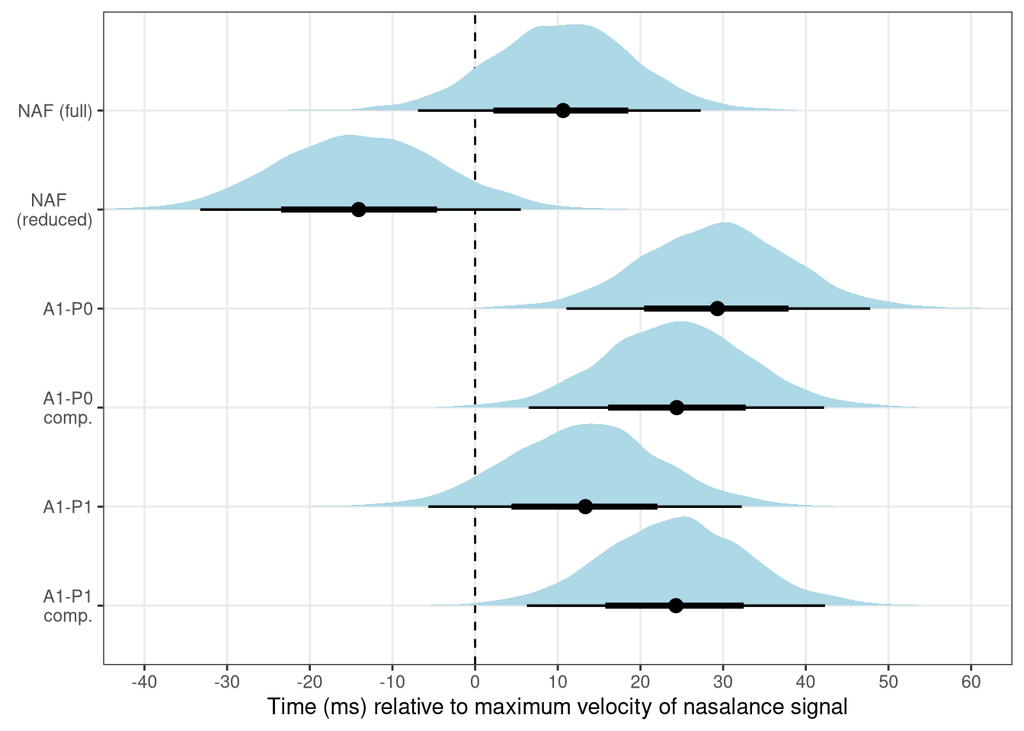

```r
posts %>%
  ggplot(aes(x = ons.diff, y = method)) +
  geom_vline(xintercept=0,lty=2) +
  geom_halfeyeh(fill='lightblue') +
  coord_cartesian(xlim=c(-40,60)) +
  ylab('') + xlab('Time (ms) relative to maximum velocity of nasalance signal') +
  scale_x_continuous(breaks=seq(-250,250,10),minor_breaks=seq(-250,250,10)) +
  scale_y_discrete(limits=c('A1-P1 comp.','A1-P1','A1-P0 comp.','A1-P0','NAF (red.)','NAF (full)'), labels=c('A1-P1\ncomp.','A1-P1','A1-P0\ncomp.','A1-P0','NAF     \n(reduced)','NAF (full)')) +
  theme_bw() + theme(plot.margin = unit(c(0.2,0.2,0.2,-0.2), 'cm'))
```

### BRM of temporal lag measure: summary statistics

In order to generate the summary statistics that are reported in the paper, we first need to get the fixed effects from the BRM:

```r
diff_fixed <- fixef(diff.mod)
```

We’ll get the lower and lower bounds of the 95% credible interval for the full NAF values (the model intercept):

```r
# Lower
diff_fixed[1,3]
```

```
## [1] -6.907851
```

```r
# Upper
diff_fixed[1,4]
```

```
## [1] 27.29337
```

Now we can find the differences for the other methods, in comparison to the model intercept (i.e. the full NAF method)…

```r
diff_diffs <- brms::posterior_samples(diff.mod, pars = 'b_') %>%
  dplyr::mutate(
    NAF = b_Intercept,
    NAFred = b_Intercept + b_methodNAFred.,
    A1P0 = b_Intercept + b_methodA1MP0,
    A1P0comp = b_Intercept + b_methodA1MP0comp.,
    A1P1 = b_Intercept + b_methodA1MP1,
    A1P1comp = b_Intercept + b_methodA1MP1comp.,
    NAFred.diff = NAFred - NAF,
    A1P0.diff = A1P0 - NAF,
    A1P0comp.diff = A1P0comp - NAF,
    A1P1.diff = A1P1 - NAF,
    A1P1comp.diff = A1P1comp - NAF
  )
```

…and generate the 95% CIs that are reported in the article:

```r
quantile(diff_diffs$NAFred.diff, probs = c(0.025, 0.975))
```

```
##       2.5%      97.5%
## -45.576433  -3.327154
```

```r
quantile(diff_diffs$A1P0.diff, probs = c(0.025, 0.975))
```

```
##       2.5%      97.5%
## -0.5179978 38.0807040
```

```r
quantile(diff_diffs$A1P0comp.diff, probs = c(0.025, 0.975))
```

```
##      2.5%     97.5%
## -6.097822 33.204585
```

```r
quantile(diff_diffs$A1P1.diff, probs = c(0.025, 0.975))
```

```
##      2.5%     97.5%
## -17.54854  22.59434
```

```r
quantile(diff_diffs$A1P1comp.diff, probs = c(0.025, 0.975))
```

```
##      2.5%     97.5%
## -5.104481 32.499338
```

## Generalized additive mixed models (GAMMs)

In order to build the GAMM, we first have to prepare the data. As part of this preparation, we convert timepoints to ms, with each 500 ms token centered on 0:

```r
gam.dat <- rbind.data.frame(
  cbind(all.dat$speaker, all.dat$vowel, 5*(all.dat$point_vwlpct-50), scale(all.dat$nasalance_z), 'nasalance'),
  cbind(all.dat$speaker, all.dat$vowel, 5*(all.dat$point_vwlpct-50), scale(all.dat$NAF), 'NAF (full)'),
  cbind(all.dat$speaker, all.dat$vowel, 5*(all.dat$point_vwlpct-50), scale(all.dat$NAF.red), 'NAF (red.)'),
  cbind(all.dat$speaker, all.dat$vowel, 5*(all.dat$point_vwlpct-50), scale(all.dat$a1p0_compensated), 'A1-P0 (comp.)')
)
colnames(gam.dat) <- c('speaker','vowel','timepoint','value','method')

# convert classes of variables as appropriate
gam.dat$value     <- as.numeric(gam.dat$value)
gam.dat$timepoint <- as.numeric(gam.dat$timepoint)
gam.dat$speaker   <- as.factor(gam.dat$speaker)
gam.dat$vowel     <- as.factor(gam.dat$vowel)
gam.dat$method    <- factor(gam.dat$method, levels=c('nasalance','NAF (full)','NAF (red.)','A1-P0 (comp.)'))
```

Because these are time-series data, correlation between samples is expected, resulting in auto-correlation of the model residuals, resulting in a violation of the model assumption of independent errors. The *bam* function can deal with this nicely, but we first need to create a separate colum to identify the beginning of each token:

```r
gam.dat$AR.start <- gam.dat$timepoint==-250
```

We’ll first have to build a base model without the auto-correlation reduced, so that we can determine how much correlation is present. Random smooths are included by speaker and vowel:

```r
m1 <- mgcv::bam(value ~ method + s(timepoint, by=method) +
                  s(timepoint, speaker, by=method, bs='fs', m=1) +
                  s(timepoint, vowel, by=method, bs='fs', m=1),
                data=gam.dat)
```

With this base model, we can now estimate the *rho* value to use in reducing auto-correlation in the final model. Plotting the results will reveal that there is a lot of correlation to get rid of!

```r
macf <- itsadug::acf_resid(m1)
```

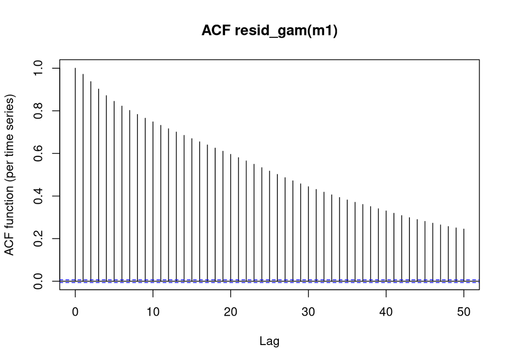

We now build the final model, with the auto-correlation reduced, by using the auto-correlation function (ACF) value at lag = 1:

```r
m2 <- mgcv::bam(value ~ method + s(timepoint, by=method) +
                  s(timepoint, speaker, by=method, bs='fs', m=1) +
                  s(timepoint, vowel, by=method, bs='fs', m=1),
                rho=macf[2], AR.start=gam.dat$AR.start, data=gam.dat)
```

Plotting the ACF of the new model reveals that the correlation has been reduced quite nicely!

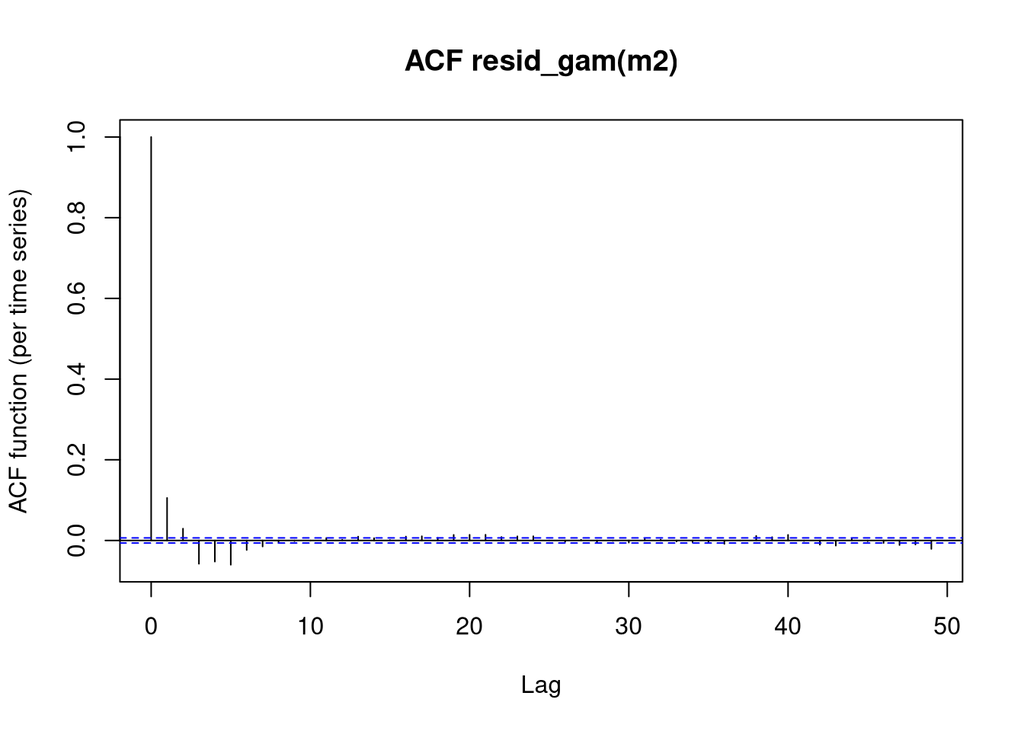

```r
itsadug::acf_resid(m2)
```

The gam.check function reveals that the number of basis functions used is appropriate for these data:

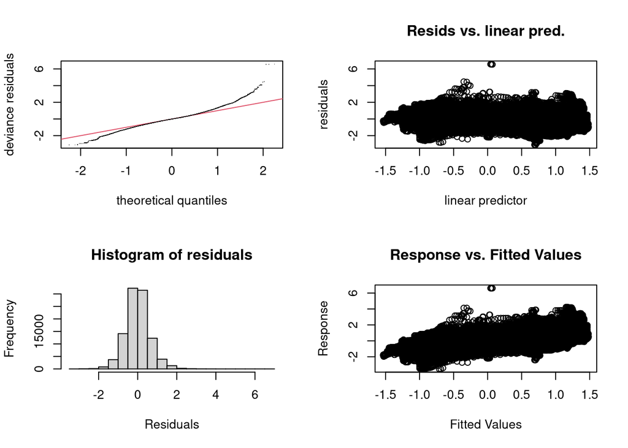

```
##
## Method: fREML   Optimizer: perf newton
## full convergence after 18 iterations.
## Gradient range [-0.0002719846,0.000903499]
## (score -67824.91 & scale 0.2590667).
## Hessian positive definite, eigenvalue range [0.0001010858,50196.05].
## Model rank =  652 / 652
##
## Basis dimension (k) checking results. Low p-value (k-index<1) may
## indicate that k is too low, especially if edf is close to k'.
##
##                                             k'   edf k-index p-value
## s(timepoint):methodnasalance              9.00  8.89    1.01    0.71
## s(timepoint):methodNAF (full)             9.00  8.72    1.01    0.65
## s(timepoint):methodNAF (red.)             9.00  8.62    1.01    0.73
## s(timepoint):methodA1-P0 (comp.)          9.00  8.21    1.01    0.75
## s(timepoint,speaker):methodnasalance     54.00 25.56    1.01    0.71
## s(timepoint,speaker):methodNAF (full)    54.00 27.50    1.01    0.73
## s(timepoint,speaker):methodNAF (red.)    54.00 31.67    1.01    0.69
## s(timepoint,speaker):methodA1-P0 (comp.) 54.00 33.77    1.01    0.74
## s(timepoint,vowel):methodnasalance       99.00  3.51    1.01    0.72
## s(timepoint,vowel):methodNAF (full)      99.00 44.23    1.01    0.77
## s(timepoint,vowel):methodNAF (red.)      99.00 50.19    1.01    0.74
## s(timepoint,vowel):methodA1-P0 (comp.)   99.00 61.63    1.01    0.71
```

```r
mgcv::gam.check(m2)
```

And a summary of the model tells us how strongly each smooth is in contributing to the model (i.e. in explaining the total variance):

```r
summary(m2)
```

```
##
## Family: gaussian
## Link function: identity
##
## Formula:
## value ~ method + s(timepoint, by = method) + s(timepoint, speaker,
##     by = method, bs = "fs", m = 1) + s(timepoint, vowel, by = method,
##     bs = "fs", m = 1)
##
## Parametric coefficients:
##                      Estimate Std. Error t value Pr(>|t|)
## (Intercept)         -0.002044   0.035688  -0.057    0.954
## methodNAF (full)     0.001636   0.061324   0.027    0.979
## methodNAF (red.)    -0.012247   0.073884  -0.166    0.868
## methodA1-P0 (comp.)  0.025747   0.137886   0.187    0.852
##
## Approximate significance of smooth terms:
##                                             edf Ref.df       F p-value
## s(timepoint):methodnasalance              8.886  8.945 126.183  <2e-16 ***
## s(timepoint):methodNAF (full)             8.718  8.829  62.355  <2e-16 ***
## s(timepoint):methodNAF (red.)             8.616  8.749  41.959  <2e-16 ***
## s(timepoint):methodA1-P0 (comp.)          8.211  8.433  17.571  <2e-16 ***
## s(timepoint,speaker):methodnasalance     25.558 53.000   1.324  <2e-16 ***
## s(timepoint,speaker):methodNAF (full)    27.497 53.000   1.692  <2e-16 ***
## s(timepoint,speaker):methodNAF (red.)    31.669 53.000   2.043  <2e-16 ***
## s(timepoint,speaker):methodA1-P0 (comp.) 33.766 53.000   2.878  <2e-16 ***
## s(timepoint,vowel):methodnasalance        3.508 98.000   0.056    0.11
## s(timepoint,vowel):methodNAF (full)      44.227 98.000   1.022  <2e-16 ***
## s(timepoint,vowel):methodNAF (red.)      50.193 98.000   1.464  <2e-16 ***
## s(timepoint,vowel):methodA1-P0 (comp.)   61.635 98.000   5.349  <2e-16 ***
## ---
## Signif. codes:  0 '***' 0.001 '**' 0.01 '*' 0.05 '.' 0.1 ' ' 1
##
## R-sq.(adj) =  0.614   Deviance explained = 61.6%
## fREML = -67825  Scale est. = 0.25907   n = 100400
```

### Figure 6

We now generate a plot object in order to extract the model fits for each method and put them into a data frame:

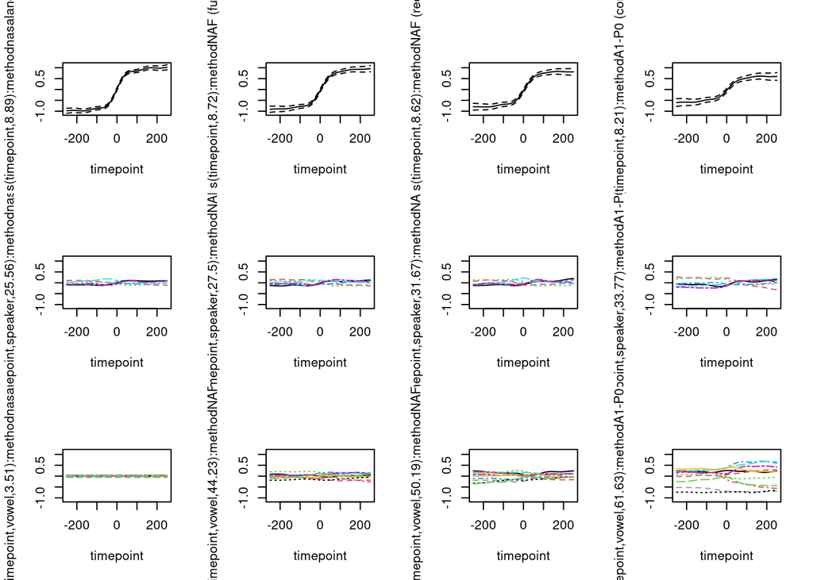

```r
pl_data <- plot(m2, pages=1)
```

```r
nasalance_pl  <- pl_data[[1]][c('x', 'fit', 'se')]
naf.full_pl   <- pl_data[[2]][c('x', 'fit', 'se')]
naf.red_pl    <- pl_data[[3]][c('x', 'fit', 'se')]
a1p0_pl       <- pl_data[[4]][c('x', 'fit', 'se')]

# create a data frame with the model fit data
gamm.plt <- rbind.data.frame(
  cbind(nasalance_pl$x, nasalance_pl$fit, nasalance_pl$se, 'nasalance'),
  cbind(a1p0_pl$x, a1p0_pl$fit, a1p0_pl$se, 'A1-P0 (comp.)'),
  cbind(naf.full_pl$x, naf.full_pl$fit, naf.full_pl$se, 'NAF (full)'),
  cbind(naf.red_pl$x, naf.red_pl$fit, naf.red_pl$se, 'NAF (red.)')
)
colnames(gamm.plt) <- c('time','fit','se','method')

# convert classes of variables as appropriate
gamm.plt$time   <- as.numeric(gamm.plt$time)
gamm.plt$fit    <- as.numeric(gamm.plt$fit)
gamm.plt$se     <- as.numeric(gamm.plt$se)
gamm.plt$method <- factor(gamm.plt$method, levels=c('nasalance','NAF (full)','NAF (red.)','A1-P0 (comp.)'))
```

Now that we have the model fits for the different methods, we can create Figure 6 from the paper:

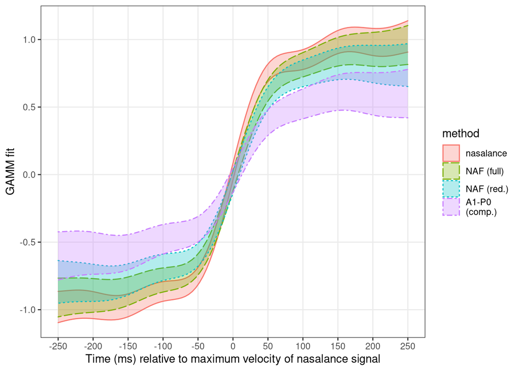

```r
ggplot(gamm.plt, aes(x=time, colour=method, group=method)) +
  geom_ribbon(aes(ymin=fit-se, ymax=fit+se, fill=method, linetype=method), alpha=0.3) +
  scale_y_continuous(name='GAMM fit',breaks=seq(-1,1,0.5),minor_breaks=seq(-1,1,0.5)) +
  scale_x_continuous(name='Time (ms) relative to maximum velocity of nasalance signal',
                     breaks=seq(-250,250,50),minor_breaks=seq(-250,250,50)) +
  scale_color_discrete(limits=c('nasalance','NAF (full)','NAF (red.)','A1-P0 (comp.)'),
                       labels=c('nasalance','NAF (full)','NAF (red.)','A1-P0\n(comp.)')) +
  scale_fill_discrete(limits=c('nasalance','NAF (full)','NAF (red.)','A1-P0 (comp.)'),
                      labels=c('nasalance','NAF (full)','NAF (red.)','A1-P0\n(comp.)')) +
  scale_linetype_manual(limits=c('nasalance','NAF (full)','NAF (red.)','A1-P0 (comp.)'),
                        labels=c('nasalance','NAF (full)','NAF (red.)','A1-P0\n(comp.)'),
                        values=c(1,5,3,4)) +
  theme_bw()
```

### Investigating random smooths

For the sake of space, the following plots are not included in the JASA article, but they may nonetheless be of interest to some readers. The random smooths from the GAMM can be plotted in order to view the within-category variation present in the data for each smooth.

First, let’s plot the inter-speaker variation (the by-speaker random smooth):

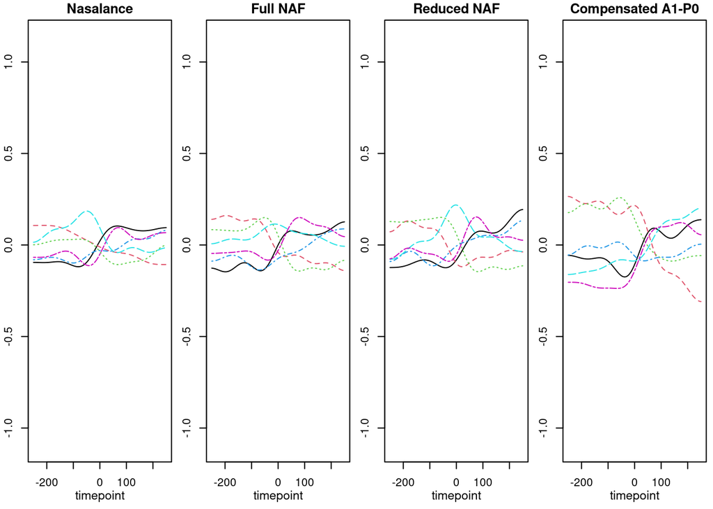

```r
par(mfrow=c(1,4), mar=c(3.5,2.1,1.5,0.5), mgp=c(2,1,0))

plot(m2,select=5,cex.lab=1.1,ylab='')
title('Nasalance', line=0.5)

plot(m2,select=6,cex.lab=1.1,ylab='')
title('Full NAF', line=0.5)

plot(m2,select=7,cex.lab=1.1,ylab='')
title('Reduced NAF', line=0.5)

plot(m2,select=8,cex.lab=1.1,ylab='')
title('Compensated A1-P0', line=0.5)
```

We can see that there is a small amount of variation across speakers for all four metrics, with the most variation observed for formant-compensated A1-P0. As mentioned in the article, the size of this variation can also be inferred from the size of the *F*-statistic in the model summary (shown above): a small amount of variation for nasalance (*F*=1.32) and the full NAF (*F*=1.69), a bit more for the reduced NAF (*F*=2.04), and yet more for formant-compensated A1-P0 (*F*=2.88).

And now let’s plot the inter-vowel variation (the by-vowel random smooth):

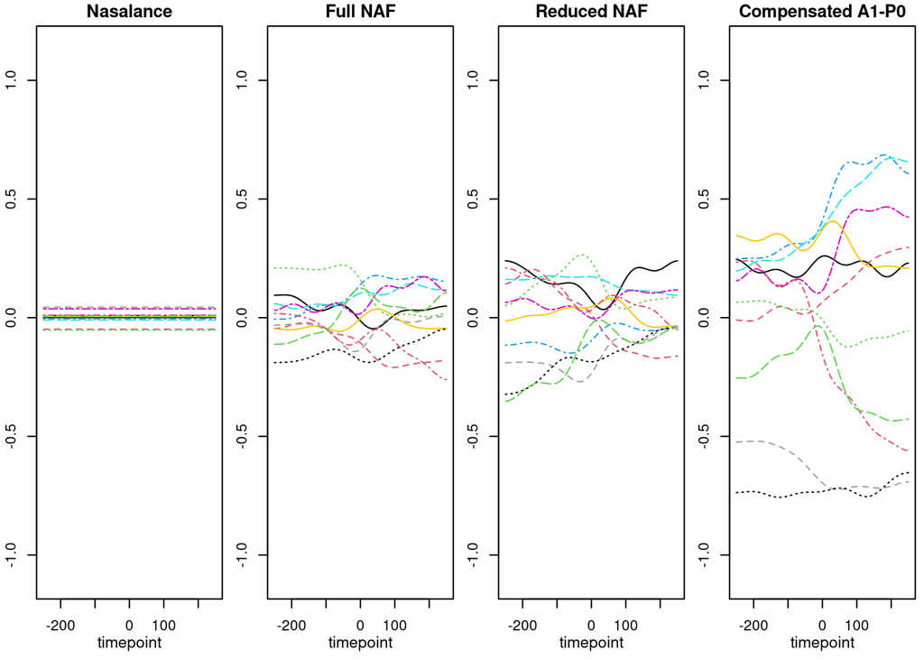

```r
par(mfrow=c(1,4), mar=c(3.5,2.1,1.5,0.5), mgp=c(2,1,0))

plot(m2,select=9,cex.lab=1.1,ylab='')
title('Nasalance', line=0.5)

plot(m2,select=10,cex.lab=1.1,ylab='')
title('Full NAF', line=0.5)

plot(m2,select=11,cex.lab=1.1,ylab='')
title('Reduced NAF', line=0.5)

plot(m2,select=12,cex.lab=1.1,ylab='')
title('Compensated A1-P0', line=0.5)
```

We can see that there is considerably more inter-vowel variation across the different methods than there was inter-speaker variation. There is essentially no variation across vowels for nasalance (*F*=0.06), a small amount of variation for the full NAF (*F*=1.02), a bit more for the reduced NAF (*F*=1.46), but quite substantial amount of variation across vowels for formant-compensated A1-P0 (*F*=5.35).

## Example implementation of NAF

This final portion of the R markdown file is concerned with Section IV.B of the article, which is an example of the practical implementation of the NAF method in the design of a study. Here we use a separate set of data that was collected specifically for this example.

Let’s first get the data and do a bit of preparation:

```r
# get the data for the example speaker, S00
speaker <- 'S00'
nas.dat <- read.csv(file=paste0('data/',speaker,'_data.csv'))

nas.dat$vowel <- as.factor(nas.dat$vowel)
nas.dat$type  <- as.factor(nas.dat$type)

# create the H1-H2 metric
nas.dat$h1h2 <- nas.dat$amp_h1 - nas.dat$amp_h2

# generate new row names for random sampling purposes
row.names(nas.dat) <- 1:nrow(nas.dat)

# scale the nasalance values for each vowel
for (vowel in unique(nas.dat$vowel)) {
  nas.dat$nasalance[nas.dat$vowel==vowel] <- scale(nas.dat$nasalance[nas.dat$vowel==vowel], center=T, scale=T)
}

# global rescaling of nasalance values
nas.dat$nasalance <- scale(nas.dat$nasalance, center=T, scale=T)
```

Now that the data has been prepared, let’s separate it into training and testing sets, and get the indexes of the samples associated with the training items:

```r
training  <- nas.dat[nas.dat$type %in% c('oral','nasal'),]
testing   <- nas.dat[nas.dat$type %in% c('nd','nt'),]

train_ind <- as.numeric(row.names(training))
```

And now we do the PCA regression:

```r
# PCA of all acoustic features (for full NAF method)
pca.full <- prcomp(nas.dat[,all.features], scale=T, center=T)

# create a data frame with the PC scores for the full acoustic feature set
pca.dat <- cbind.data.frame(training$type, pca.full$x[train_ind,])
colnames(pca.dat)[1] <- 'nasality'
pca.dat$nasality <- as.character(pca.dat$nasality)

# convert 'oral' and 'nasal' to numeric 0 and 1
pca.dat$nasality[pca.dat$nasality=='oral'] <- 0
pca.dat$nasality[pca.dat$nasality=='nasal'] <- 1
pca.dat$nasality <- as.numeric(pca.dat$nasality)

# build the linear regression model with PC scores as predictors
lm.mod <- lm(nasality ~ ., data=pca.dat)
```

With this linear regression model, we can create NAF values for the testing items:

```r
testing$NAF <- predict(lm.mod, newdata=as.data.frame(pca.full$x[-train_ind,]), type='response')
```

And then scale and smooth the data from the three metrics before examining the results:

```r
# scale the NAF values and formant-compensated A1-P0 values
testing$NAF <- scale(testing$NAF, center=T, scale=T)
testing$a1p0_compensated <- scale(-testing$a1p0_compensated, center=T, scale=T)

# smooth the NAF and A1-P0 measurements for all tokens
for (token in unique(testing$token)) {
  token.dat <- testing[testing$token==token,]

  testing$NAF[testing$token==token]               <- smooth(token.dat$NAF)
  testing$a1p0_compensated[testing$token==token]  <- smooth(token.dat$a1p0_compensated)
}
```

A bit of data wrangling needs be performed before building the GAMM:

```r
# separate the data for the three metrics
dat1 <- cbind(testing[,c('type','vowel','repetition','timepoint','nasalance')],'nasalance')
dat2 <- cbind(testing[,c('type','vowel','repetition','timepoint','NAF')],'NAF')
dat3 <- cbind(testing[,c('type','vowel','repetition','timepoint','a1p0_compensated')],'A1P0')

# rename columns
colnames(dat1) <- c('type','vowel','repetition','timepoint','value','method')
colnames(dat2) <- c('type','vowel','repetition','timepoint','value','method')
colnames(dat3) <- c('type','vowel','repetition','timepoint','value','method')

# combine into one data frame
gam.dat <- rbind.data.frame(dat1,dat2,dat3)

# convert classes of variables as appropriate
gam.dat$value       <- as.numeric(gam.dat$value)
gam.dat$timepoint   <- as.numeric(gam.dat$timepoint)
gam.dat$vowel       <- as.factor(gam.dat$vowel)
gam.dat$repetition  <- as.ordered(gam.dat$repetition)
gam.dat$method      <- factor(gam.dat$method, levels=c('nasalance','NAF','A1P0'))
gam.dat$type2       <- paste0(gam.dat$method,'-',gam.dat$type)
gam.dat$type2       <- factor(gam.dat$type2, levels=c('nasalance-nd','nasalance-nt',
                                                      'NAF-nd','NAF-nt',
                                                      'A1P0-nd','A1P0-nt'))
```

The process in building the GAMM is the same as before, so we won’t go through it step by step again:

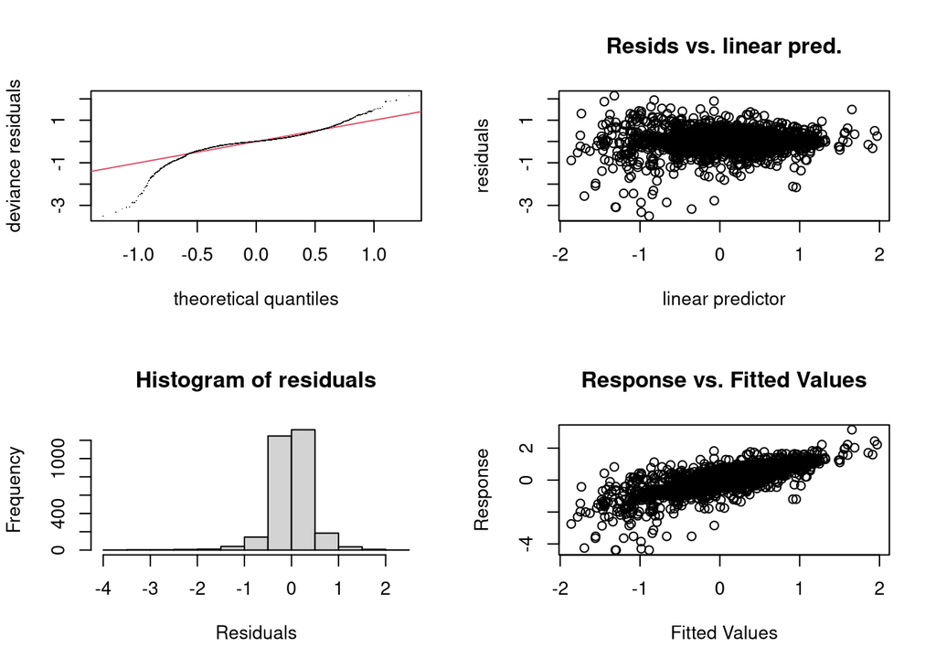

```
##
## Method: fREML   Optimizer: perf newton
## full convergence after 23 iterations.
## Gradient range [-2.740221e-06,1.553673e-05]
## (score 615.7345 & scale 0.1310094).
## Hessian positive definite, eigenvalue range [2.106579e-06,1495.133].
## Model rank =  870 / 870
##
## Basis dimension (k) checking results. Low p-value (k-index<1) may
## indicate that k is too low, especially if edf is close to k'.
##
##                                              k'   edf k-index p-value
## s(timepoint):type2nasalance-nd             9.00  5.35    1.07    1.00
## s(timepoint):type2nasalance-nt             9.00  5.46    1.07    1.00
## s(timepoint):type2NAF-nd                   9.00  4.58    1.07    1.00
## s(timepoint):type2NAF-nt                   9.00  3.89    1.07    1.00
## s(timepoint):type2A1P0-nd                  9.00  1.00    1.07    1.00
## s(timepoint):type2A1P0-nt                  9.00  2.89    1.07    0.99
## s(timepoint,vowel):type2nasalance-nd      45.00 31.84    1.07    1.00
## s(timepoint,vowel):type2nasalance-nt      45.00 27.54    1.07    1.00
## s(timepoint,vowel):type2NAF-nd            45.00 32.75    1.07    1.00
## s(timepoint,vowel):type2NAF-nt            45.00 32.25    1.07    1.00
## s(timepoint,vowel):type2A1P0-nd           45.00 19.25    1.07    0.99
## s(timepoint,vowel):type2A1P0-nt           45.00 26.69    1.07    1.00
## s(timepoint,repetition):type2nasalance-nd 90.00  3.07    1.07    1.00
## s(timepoint,repetition):type2nasalance-nt 90.00  1.68    1.07    1.00
## s(timepoint,repetition):type2NAF-nd       90.00 34.91    1.07    1.00
## s(timepoint,repetition):type2NAF-nt       90.00 47.57    1.07    1.00
## s(timepoint,repetition):type2A1P0-nd      90.00  6.67    1.07    1.00
## s(timepoint,repetition):type2A1P0-nt      90.00  7.26    1.07    1.00
```

```r
# create AR.start variable to reduce correlation starting at the beginning of each token
gam.dat$AR.start <- gam.dat$timepoint==1

# build base model without auto-correlation reduced
# random smooths for vowel and item repetition
m1 <- mgcv::bam(value ~ type2 + s(timepoint, by=type2) +
                  s(timepoint, vowel, by=type2, bs='fs', m=1) +
                  s(timepoint, repetition, by=type2, bs='fs', m=1),
                data=gam.dat)

# estimate the rho value to use in reducing auto-correlation in the model
macf <- itsadug::acf_resid(m1, plot=F)

# build the new model, with auto-correlation reduced
m2 <- mgcv::bam(value ~ type2 + s(timepoint, by=type2) +
                  s(timepoint, vowel, by=type2, bs='fs', m=1) +
                  s(timepoint, repetition, by=type2, bs='fs', m=1),
                rho=macf[2], AR.start=gam.dat$AR.start, data=gam.dat)

# the gam.check function reveals that the number of basis functions used is appropriate for these data
gam.check(m2)
```

[figure not shown]

```r
# generate a plot object in order to extract the model fits for each method
pl_data <- plot(m2, pages=1)
```

```r
nasalance.nd_pl <- pl_data[[1]][c('x', 'fit', 'se')]
nasalance.nt_pl <- pl_data[[2]][c('x', 'fit', 'se')]
naf.nd_pl       <- pl_data[[3]][c('x', 'fit', 'se')]
naf.nt_pl       <- pl_data[[4]][c('x', 'fit', 'se')]
a1p0.nd_pl      <- pl_data[[5]][c('x', 'fit', 'se')]
a1p0.nt_pl      <- pl_data[[6]][c('x', 'fit', 'se')]


# create a data frame with the model fit of the nasalance data
gamm.plt <- rbind.data.frame(
  cbind(nasalance.nd_pl$x,nasalance.nd_pl$fit,nasalance.nd_pl$se,'nasalance-nd'),
  cbind(nasalance.nt_pl$x,nasalance.nt_pl$fit,nasalance.nt_pl$se,'nasalance-nt')
)
colnames(gamm.plt) <- c('time','fit','se','method')
gamm.plt$time   <- as.numeric(gamm.plt$time)
gamm.plt$fit    <- as.numeric(gamm.plt$fit)
gamm.plt$se     <- as.numeric(gamm.plt$se)
gamm.plt$method <- factor(gamm.plt$method, levels=c('nasalance-nd','nasalance-nt'))
```

### Figure 7

```r
# create a plot object for the nasalance GAMM fit
p1 <- ggplot(gamm.plt, aes(x=time, colour=method, group=method)) +
  geom_ribbon(aes(ymin=fit-se, ymax=fit+se, fill=method, linetype=method), alpha=0.3) +
  scale_fill_discrete(name = 'Context', labels = c('/nd/','/nt/')) +
  scale_colour_discrete(name = 'Context', labels = c('/nd/','/nt/')) +
  scale_linetype_discrete(name = 'Context', labels = c('/nd/','/nt/')) +
  ggtitle('Nasalance') +
  scale_y_continuous(name='GAMM fit',breaks=seq(-2,2,0.5),minor_breaks=seq(-2,2,0.5),limits=c(-1.6,1.1)) +
  scale_x_continuous(name='Percentage of vowel interval',
                     labels=seq(0,100,20),
                     breaks=seq(0,10,2),minor_breaks=seq(0,10,2)) +
  theme_bw()


# create a data frame with the model fit of the full NAF data
gamm.plt <- rbind.data.frame(
  cbind(naf.nd_pl$x,naf.nd_pl$fit,naf.nd_pl$se,'NAF-nd'),
  cbind(naf.nt_pl$x,naf.nt_pl$fit,naf.nt_pl$se,'NAF-nt')
)
colnames(gamm.plt) <- c('time','fit','se','method')
gamm.plt$time   <- as.numeric(gamm.plt$time)
gamm.plt$fit    <- as.numeric(gamm.plt$fit)
gamm.plt$se     <- as.numeric(gamm.plt$se)
gamm.plt$method <- factor(gamm.plt$method, levels=c('NAF-nd','NAF-nt'))

# create a plot object for the NAF GAMM fit
p2 <- ggplot(gamm.plt, aes(x=time, colour=method, group=method)) +
  geom_ribbon(aes(ymin=fit-se, ymax=fit+se, fill=method, linetype=method), alpha=0.3) +
  scale_fill_discrete(name = 'Context', labels = c('/nd/','/nt/')) +
  scale_colour_discrete(name = 'Context', labels = c('/nd/','/nt/')) +
  scale_linetype_discrete(name = 'Context', labels = c('/nd/','/nt/')) +
  ggtitle('Full NAF method') +
  scale_y_continuous(name='GAMM fit',breaks=seq(-2,2,0.5),minor_breaks=seq(-2,2,0.5),limits=c(-1.6,1.1)) +
  scale_x_continuous(name='Percentage of vowel interval',
                     labels=seq(0,100,20),
                     breaks=seq(0,10,2),minor_breaks=seq(0,10,2)) +
  theme_bw()


# create a data frame with the model fit of the formant-compensated A1-P0 data
gamm.plt <- rbind.data.frame(
  cbind(a1p0.nd_pl$x,a1p0.nd_pl$fit,a1p0.nd_pl$se,'A1P0-nd'),
  cbind(a1p0.nt_pl$x,a1p0.nt_pl$fit,a1p0.nt_pl$se,'A1P0-nt')
)
colnames(gamm.plt) <- c('time','fit','se','method')
gamm.plt$time   <- as.numeric(gamm.plt$time)
gamm.plt$fit    <- as.numeric(gamm.plt$fit)
gamm.plt$se     <- as.numeric(gamm.plt$se)
gamm.plt$method <- factor(gamm.plt$method, levels=c('A1P0-nd','A1P0-nt'))

# create a plot object for the A1-P0 GAMM fit
p3 <- ggplot(gamm.plt, aes(x=time, colour=method, group=method)) +
  geom_ribbon(aes(ymin=fit-se, ymax=fit+se, fill=method, linetype=method), alpha=0.3) +
  scale_fill_discrete(name = 'Context', labels = c('/nd/','/nt/')) +
  scale_colour_discrete(name = 'Context', labels = c('/nd/','/nt/')) +
  scale_linetype_discrete(name = 'Context', labels = c('/nd/','/nt/')) +
  ggtitle('Formant-compensated A1-P0') +
  scale_y_continuous(name='GAMM fit',breaks=seq(-2,2,0.5),minor_breaks=seq(-2,2,0.5),limits=c(-1.6,1.1)) +
  scale_x_continuous(name='Percentage of vowel interval',
                     labels=seq(0,100,20),
                     breaks=seq(0,10,2),minor_breaks=seq(0,10,2)) +
  theme_bw()
```

And finally, we now combine the plot objects to create Figure 7 from the article:

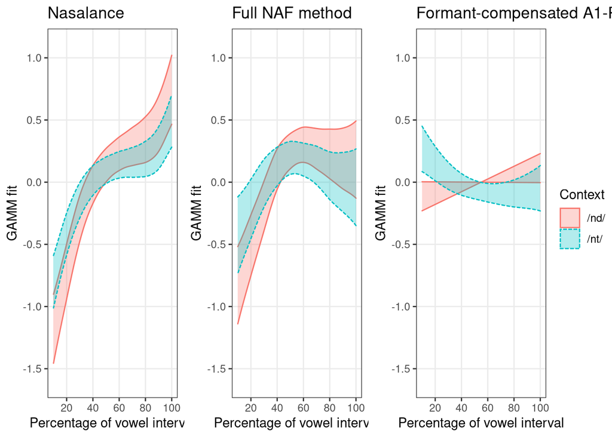

```r
# Figure 7
par(mfrow=c(1,3), mar=c(3.5,2.1,1.5,0.5), mgp=c(2,1,0))
ggarrange(p1, p2, p3, ncol=3, nrow=1, common.legend = TRUE, legend='right')
```